# DSC5103 Assignment 4

Regularization Methods in Classification

Tong Wang

Oct 2015

In this assignment, we will apply regularization methods (Ridge Regression, LASSO, and Elastic Net) to a classification problem, and compare them with traditional Logistic Regression.

### Data Preparation

First, let us get the data. We will use the **Heart** data from the textbook, available at http://www-bcf.usc.edu/~gareth/ISL/Heart.csv.

```r
heart <- read.csv(file="http://www-bcf.usc.edu/~gareth/ISL/Heart.csv", row.names=1)
summary(heart)
```

```
##       Age             Sex                ChestPain       RestBP           Chol            Fbs            RestECG
##  Min.   :29.00   Min.   :0.0000   asymptomatic:144   Min.   : 94.0   Min.   :126.0   Min.   :0.0000   Min.   :0.0000
##  1st Qu.:48.00   1st Qu.:0.0000   nonanginal  : 86   1st Qu.:120.0   1st Qu.:211.0   1st Qu.:0.0000   1st Qu.:0.0000
##  Median :56.00   Median :1.0000   nontypical  : 50   Median :130.0   Median :241.0   Median :0.0000   Median :1.0000
##  Mean   :54.44   Mean   :0.6799   typical     : 23   Mean   :131.7   Mean   :246.7   Mean   :0.1485   Mean   :0.9901
##  3rd Qu.:61.00   3rd Qu.:1.0000                      3rd Qu.:140.0   3rd Qu.:275.0   3rd Qu.:0.0000   3rd Qu.:2.0000
##  Max.   :77.00   Max.   :1.0000                      Max.   :200.0   Max.   :564.0   Max.   :1.0000   Max.   :2.0000
##
##      MaxHR           ExAng           Oldpeak         Slope             Ca                 Thal      AHD
##  Min.   : 71.0   Min.   :0.0000   Min.   :0.00   Min.   :1.000   Min.   :0.0000   fixed     : 18   No :164
##  1st Qu.:133.5   1st Qu.:0.0000   1st Qu.:0.00   1st Qu.:1.000   1st Qu.:0.0000   normal    :166   Yes:139
##  Median :153.0   Median :0.0000   Median :0.80   Median :2.000   Median :0.0000   reversable:117
##  Mean   :149.6   Mean   :0.3267   Mean   :1.04   Mean   :1.601   Mean   :0.6722   NA's      :  2
##  3rd Qu.:166.0   3rd Qu.:1.0000   3rd Qu.:1.60   3rd Qu.:2.000   3rd Qu.:1.0000
##  Max.   :202.0   Max.   :1.0000   Max.   :6.20   Max.   :3.000   Max.   :3.0000
##                                                                  NA's   :4
```

The task is to use the features to predict **AHD**, binary outcome related to some heart disease.

Some cleaning is necessary because there are NA’s and also several categorical variables stored as numerical.

```r
# clean the NA's
heart <- na.omit(heart)
# convert to factors
heart$Sex <- as.factor(heart$Sex)
heart$Fbs <- as.factor(heart$Fbs)
heart$RestECG <- as.factor(heart$RestECG)
heart$ExAng <- as.factor(heart$ExAng)
heart$Slope <- as.factor(heart$Slope)
heart$Ca <- as.factor(heart$Ca)
summary(heart)
```

```
##       Age        Sex            ChestPain       RestBP           Chol       Fbs     RestECG     MaxHR       ExAng
##  Min.   :29.00   0: 96   asymptomatic:142   Min.   : 94.0   Min.   :126.0   0:254   0:147   Min.   : 71.0   0:200
##  1st Qu.:48.00   1:201   nonanginal  : 83   1st Qu.:120.0   1st Qu.:211.0   1: 43   1:  4   1st Qu.:133.0   1: 97
##  Median :56.00           nontypical  : 49   Median :130.0   Median :243.0           2:146   Median :153.0
##  Mean   :54.54           typical     : 23   Mean   :131.7   Mean   :247.4                   Mean   :149.6
##  3rd Qu.:61.00                              3rd Qu.:140.0   3rd Qu.:276.0                   3rd Qu.:166.0
##  Max.   :77.00                              Max.   :200.0   Max.   :564.0                   Max.   :202.0
##     Oldpeak      Slope   Ca              Thal      AHD
##  Min.   :0.000   1:139   0:174   fixed     : 18   No :160
##  1st Qu.:0.000   2:137   1: 65   normal    :164   Yes:137
##  Median :0.800   3: 21   2: 38   reversable:115
##  Mean   :1.056           3: 20
##  3rd Qu.:1.600
##  Max.   :6.200
```

Next, we will prepare the training and test dataset for later model comparison.

```r
# split training and test data 50/50
N <- nrow(heart)
set.seed(456)
train.index <- sample(1:N, round(N/2))
test.index <- - train.index
```

Because function **glmnet()** only takes data in matrix form, we need a copy of the training and test data in matrix form.

```r
# construct x and y matrix for glmnet()
x <- model.matrix(AHD ~ ., heart[train.index, ])[,-1]
y <- heart[train.index, "AHD"]
x.test <- model.matrix(AHD ~ ., heart[-train.index, ])[,-1]
y.test <- heart[-train.index, "AHD"]
```

### Q1. Logistic Regression as a benchmark.

Find the optimal Logistic Regression model with **stepAIC()** using the training data, and use the model to predict using the test data.

```r
library("MASS")
glm.fit<-glm(AHD~., family=binomial(), data=heart[train.index,])
reg.model<- stepAIC(glm.fit, direction="both")
```

```
## Start:  AIC=115.68
## AHD ~ Age + Sex + ChestPain + RestBP + Chol + Fbs + RestECG +
##     MaxHR + ExAng + Oldpeak + Slope + Ca + Thal
##
##             Df Deviance    AIC
## - RestECG    2   73.808 111.81
## - Fbs        1   73.804 113.80
## - Oldpeak    1   73.854 113.85
## - ChestPain  3   78.011 114.01
## - ExAng      1   74.629 114.63
## - Chol       1   75.175 115.17
## - Age        1   75.643 115.64
## <none>           73.684 115.68
## - Thal       2   80.524 118.52
## - MaxHR      1   79.366 119.37
## - Slope      2   82.948 120.95
## - Sex        1   81.361 121.36
## - RestBP     1   85.108 125.11
## - Ca         3   97.094 133.09
##
## Step:  AIC=111.81
## AHD ~ Age + Sex + ChestPain + RestBP + Chol + Fbs + MaxHR + ExAng +
##     Oldpeak + Slope + Ca + Thal
##
##             Df Deviance    AIC
## - Fbs        1   73.890 109.89
## - Oldpeak    1   74.098 110.10
## - ChestPain  3   78.103 110.10
## - ExAng      1   74.742 110.74
## - Chol       1   75.477 111.48
## - Age        1   75.662 111.66
## <none>           73.808 111.81
## - Thal       2   80.541 114.54
## - MaxHR      1   79.422 115.42
## + RestECG    2   73.684 115.68
## - Slope      2   83.551 117.55
## - Sex        1   81.904 117.90
## - RestBP     1   85.924 121.92
## - Ca         3   97.554 129.55
##
```

[output cut: 63 more lines]

```
##             Df Deviance    AIC
## <none>           80.318 106.32
## + Chol       1   78.523 106.52
## - ExAng      1   83.288 107.29
## - Age        1   83.609 107.61
## + Fbs        1   79.976 107.98
## + Oldpeak    1   80.053 108.05
## + ChestPain  3   76.201 108.20
## - Thal       2   86.465 108.47
## + RestECG    2   79.966 109.97
## - Sex        1   87.002 111.00
## - MaxHR      1   88.063 112.06
## - Slope      2   90.503 112.50
## - RestBP     1   96.124 120.12
## - Ca         3  105.738 125.74
```

```r
AHD.Pred<-predict(reg.model, newdata = data.frame(heart[-train.index,-14 ]),type="response")
test<- heart[-train.index,]
```

### Q2. Ridge Regression.

Fit a Ridge Regression model on the training data, use cross-validtion to find the optimal $\lambda$, and use the optimal model to predict on the test data.

```r
library("glmnet")
```

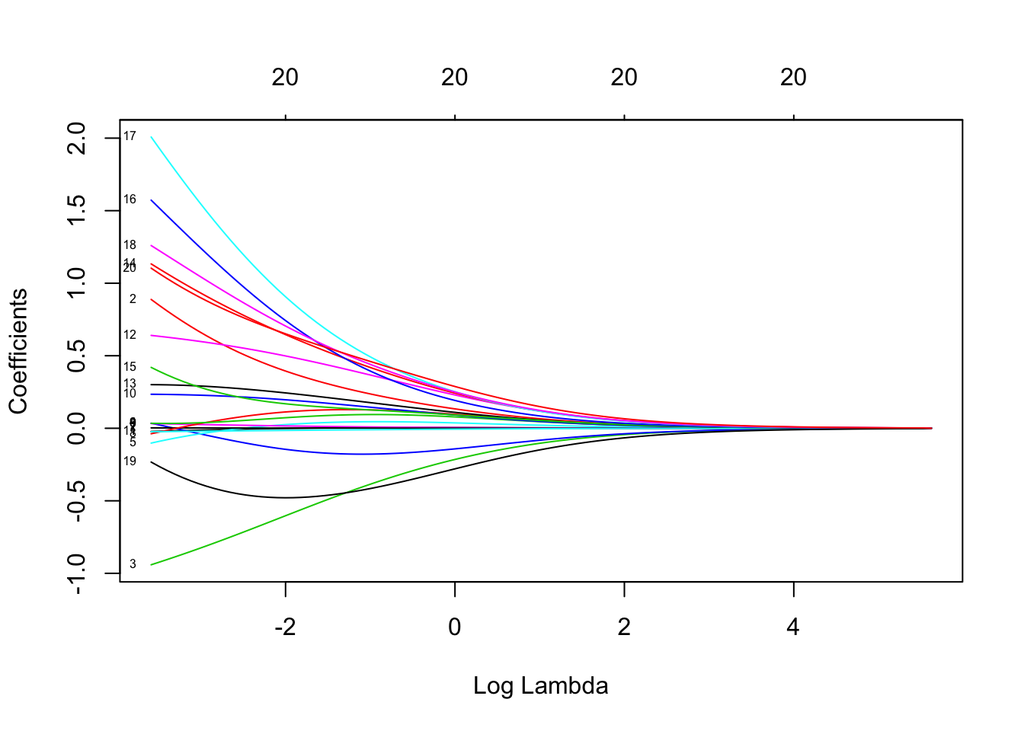

```r
ridge.mod <- glmnet(x, y, family="binomial",alpha=0)
plot(ridge.mod, xvar="lambda", label=TRUE)
```

```r
#CV to find the optimal lambda
set.seed(999)
ridge.cv <- cv.glmnet(x, y, alpha=0, family="binomial")

# optimal lambda
ridge.lam <- ridge.cv$lambda.min

#Using optimal model to predict on the test data
AHDpredR<- predict(ridge.cv, type="response", s="lambda.min",newx = x.test )
AHDpredR.test<- ifelse(AHDpredR >0.5, "YES", "NO")
```

### Q3. LASSO.

Fit a LASSO model on the training data, use cross-validtion to find the optimal $\lambda$, and use the optimal model to predict on the test data.

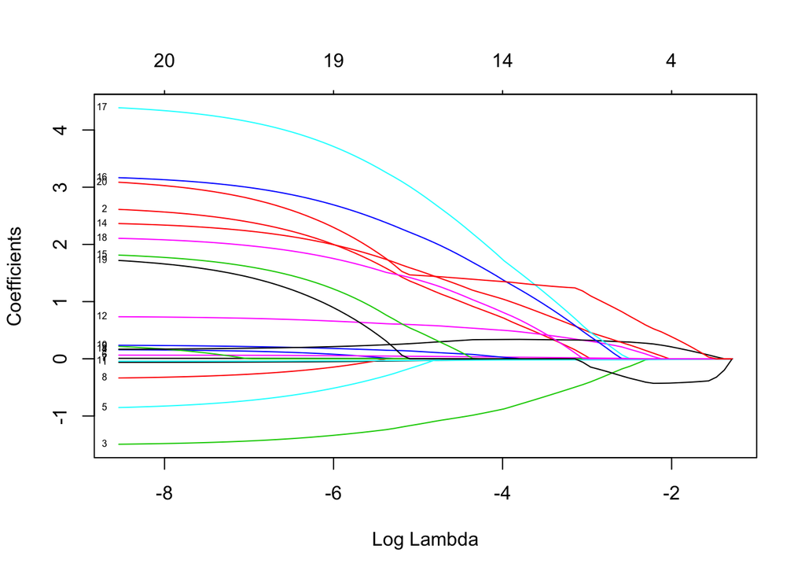

```r
lasso.mod <- glmnet(x, y, family="binomial",alpha=1)
plot(lasso.mod, xvar="lambda", label=TRUE)
```

```r
#CV to find the optimal lambda
set.seed(999)
lasso.cv <- cv.glmnet(x, y, alpha=1, family="binomial")

# optimal lambda
lasso.lam <- lasso.cv$lambda.min

#Using optimal model to predict on the test data
AHDpredL<- predict(lasso.cv, type="response", s=lasso.lam,newx = x.test )
AHDpredL.test<- ifelse(AHDpredL >0.5, "YES", "NO")
```

### Q4. Elastic Net.

Fit an Elastic Net model on the training data, use cross-validtion to find the optimal $\alpha$ and $\lambda$, and use the optimal model to predict on the test data.

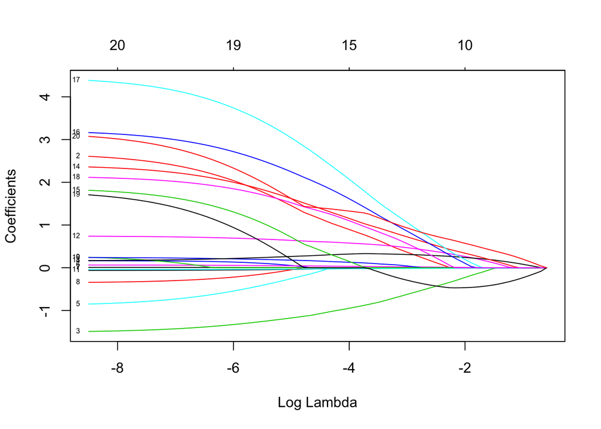

```r
elasnet.mod <- glmnet(x, y, family="binomial",alpha=0.5)
plot(elasnet.mod, xvar="lambda", label=TRUE)
```

```r
alpha <- seq(0,1,0.01)
folds <- sample(1:10, size=length(y), replace=TRUE)

#CV to find the optimal lambda & alpha
set.seed(999)
elasnet.cvm<- data.frame(alpha=alpha, cvmin=0)
for (k in alpha) {
  elasnet.cv <- cv.glmnet(x, y, alpha=k, foldid=folds, family="binomial")
  elasnet.cvm[elasnet.cvm$alpha==k,"cvmin"]<- min(elasnet.cv$cvm)
}

#optimal alpha
opt.alpha<-  elasnet.cvm$alpha[elasnet.cvm$cvmin == min(elasnet.cvm$cvmin)]

#optimal model
elasnet.optcv <- cv.glmnet(x, y, alpha=opt.alpha, family="binomial")

# optimal lambda
elasnet.lam <- elasnet.optcv$lambda.min

#prediction from the optimal model
AHDpredE<- predict(elasnet.optcv, type="response", s=elasnet.lam,newx = x.test )
AHDpredE.test<- ifelse(AHDpredE >0.5, "YES", "NO")
```

### Q5. Compare the above-studied model predictions in terms of misclassification rate, ROC, and AUC.

```r
library("ROCR")
```

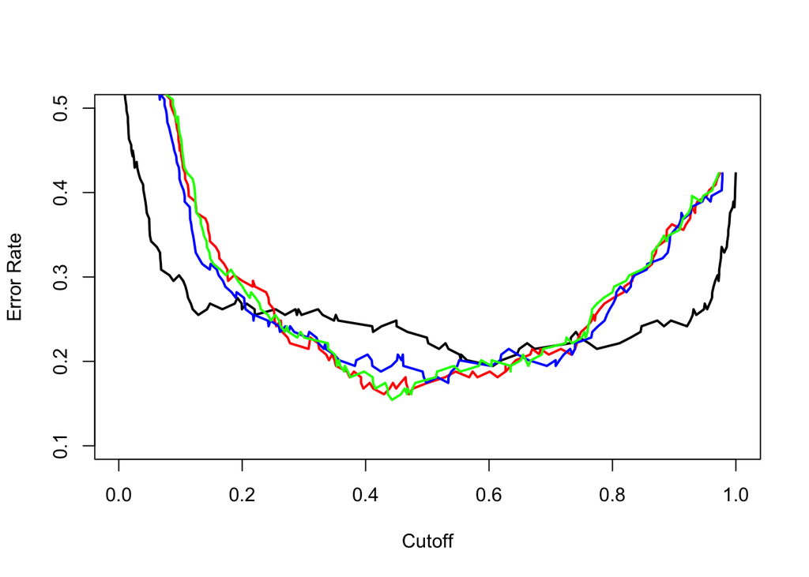

```r
logistic.pred<- prediction(AHD.Pred, y.test)
ridge.pred <- prediction(AHDpredR, y.test)
lasso.pred <- prediction(AHDpredL, y.test)
elasnet.pred <- prediction(AHDpredE, y.test)


# misclassification rate
logistic.err <- performance(logistic.pred, measure = "err")
ridge.err <- performance(ridge.pred, measure = "err")
lasso.err <- performance(lasso.pred, measure = "err")
elasnet.err <- performance(elasnet.pred, measure = "err")

plot(logistic.err, lwd=2, col="black", ylim=c(0.1, 0.5))
plot(ridge.err, lwd=2, add=TRUE, col="red")
plot(lasso.err, lwd=2, add=TRUE, col="blue")
plot(elasnet.err, lwd=2, add=TRUE, col="green")
```

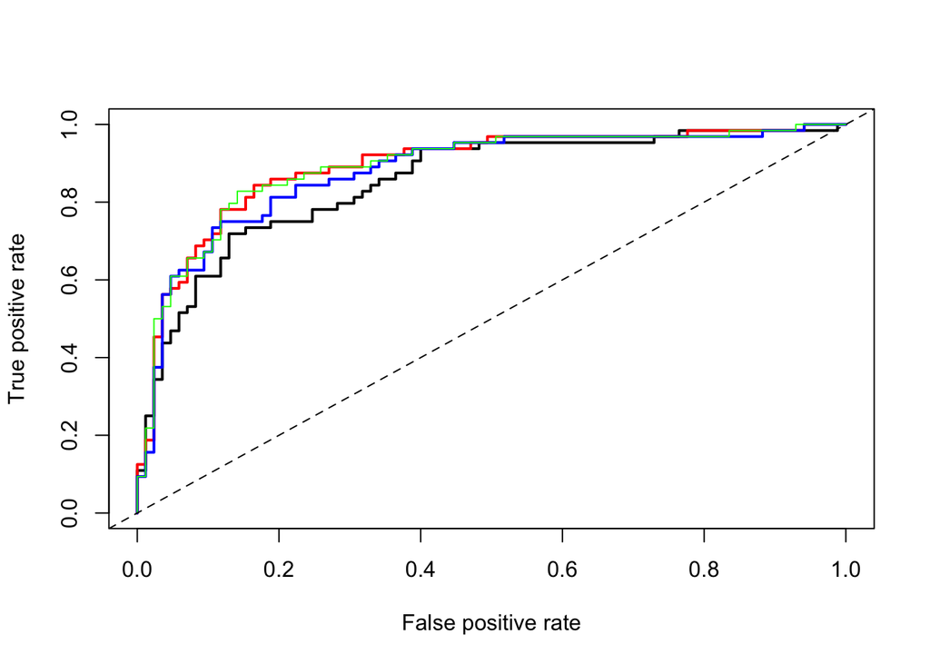

```r
# ROC plot
logistic.ROC <- performance(logistic.pred, measure = "tpr", x.measure = "fpr")
ridge.ROC <- performance(ridge.pred, measure = "tpr", x.measure = "fpr")
lasso.ROC <- performance(lasso.pred, measure = "tpr", x.measure = "fpr")
elasnet.ROC <- performance(elasnet.pred, measure = "tpr", x.measure = "fpr")

plot(logistic.ROC, lwd=2, col="black")
plot(ridge.ROC, lwd=2, add=TRUE, col="red")
plot(lasso.ROC, lwd=2, add=TRUE, col="blue")
plot(elasnet.ROC, add=TRUE, col="green")
abline(a=0, b=1, lty=2) # diagonal line
```

```r
# AUC
logistic.AUC <- as.numeric(performance(logistic.pred, "auc")@y.values)
ridge.AUC <- as.numeric(performance(ridge.pred, "auc")@y.values)
lasso.AUC <- as.numeric(performance(lasso.pred, "auc")@y.values)
elasnet.AUC <- as.numeric(performance(elasnet.pred, "auc")@y.values)
modelAUC<- data.frame(model.type=c("Logistic","Ridge", "Lasso", "Elasnet"), AUC=c(logistic.AUC, ridge.AUC, lasso.AUC, elasnet.AUC))
best.model<- modelAUC[modelAUC$AUC==max(modelAUC$AUC),]
best.model
```

```
##   model.type       AUC
## 2      Ridge 0.8917279
```